# Section 13: One-Sample Mean Inference

```r
library(tidyverse)
```

## Sampling distribution of mean

### Data tidying

`cat_breeds_clean.csv` contains data on characteristics of domestic cats of different breeds.

```r
cats <- read_csv("../../data/cat_breeds_clean.csv")
```

```
## Error:
## ! '../../data/cat_breeds_clean.csv' does not exist in current working directory ('C:/Users/19203/OneDrive/Desktop/STAT240/LECTURES/13-single-mean').
```

### Data exploration

Let’s look at the breed and sex distribution of the cats in the data.

```r
cats %>%
ggplot(aes(x = Sex)) +
  geom_bar() +
  xlab("") +
  ylab("# of Records") +
  ggtitle("Cat Breeds") +
  facet_wrap(~Breed)
```

```
## Error:
## ! object 'cats' not found
```

```r
cats %>%
ggplot(aes(x = Sex, fill = Fixed)) +
  geom_bar() +
  xlab("") +
  ylab("# of Records") +
  ggtitle("Cat Breeds") +
  facet_wrap(~Breed)
```

```
## Error:
## ! object 'cats' not found
```

Let’s focus on a single group: adult male fixed ragdoll cats.

```r
cats_small <- cats %>%
  filter(Age_in_years >= 1) %>%
  filter(Sex == "male", Breed == "Ragdoll", Fixed == T)
```

```
## Error:
## ! object 'cats' not found
```

```r
nrow(cats_small)
```

```
## Error:
## ! object 'cats_small' not found
```

```r
ggplot(cats_small, aes(x = Sleep_time_hours))+
  geom_histogram() +
  ggtitle("Daily Sleep, Adult Male (fixed) Ragdoll Cats")
```

```
## Error:
## ! object 'cats_small' not found
```

Let’s visualize the sampling distribution of a sample mean.

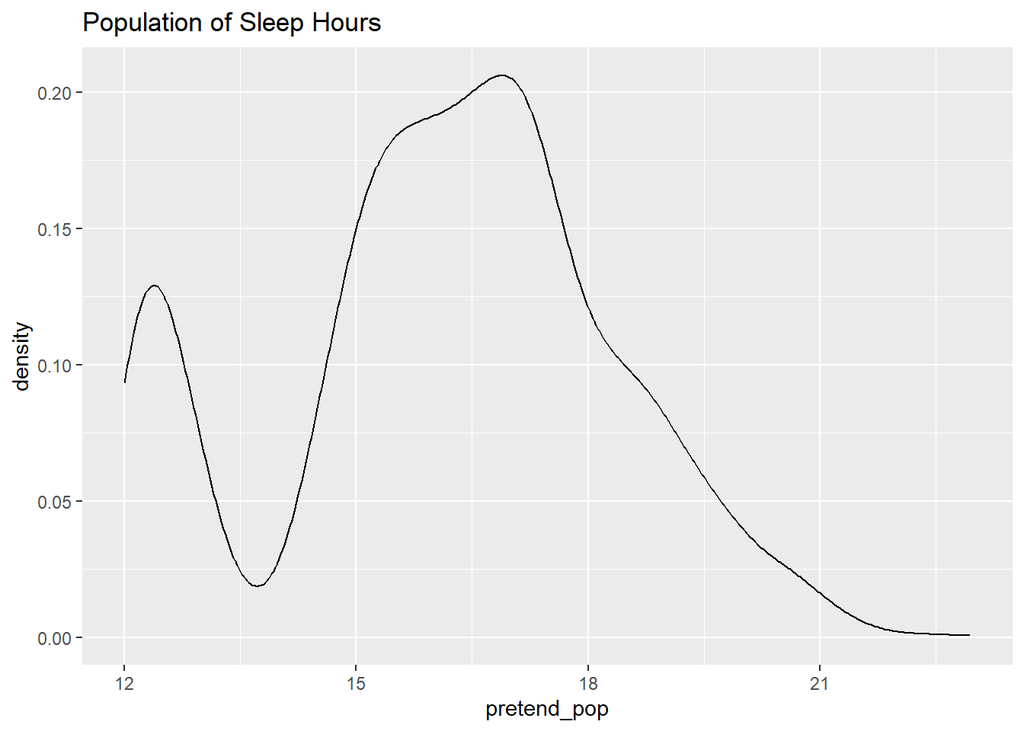

```r
# Create a fake "population" of sleep hours
set.seed(3421)
pretend_pop <- c(2*rbeta(400, 1, 3) + 12, 10*rbeta(2000, 2, 5) + 14)

ggplot(mapping = aes(x = pretend_pop)) +
  geom_density() +
  labs(title = "Population of Sleep Hours")
```

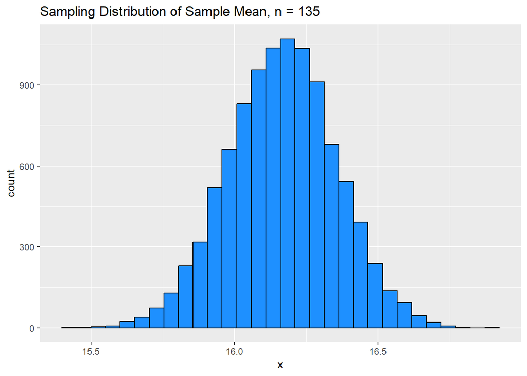

```r
random_means <- tibble(x = replicate(n = 10000,
                       mean(sample(pretend_pop, 135, replace = T)))
                                    )


ggplot(random_means) +
  geom_histogram(aes(x = x),
                 color = "black", fill = "dodgerblue") +
  labs(title = "Sampling Distribution of Sample Mean, n = 135")
```

It has a normal shape, centered at the original population mean. In our case, the observed mean is $\bar{x} = 16.02$.

```r
cats_summary <- cats_small %>%
  summarize(averageTime = mean(Sleep_time_hours),
            sdTime = sd(Sleep_time_hours),
            n = n())
```

```
## Error:
## ! object 'cats_small' not found
```

```r
cats_summary
```

```
## Error:
## ! object 'cats_summary' not found
```

## CI for mean

Let’s save the summary values needed to build a CI.

```r
xbar <- cats_summary$averageTime
```

```
## Error:
## ! object 'cats_summary' not found
```

```r
s <- cats_summary$sdTime
```

```
## Error:
## ! object 'cats_summary' not found
```

```r
n <- cats_summary$n
```

```
## Error:
## ! object 'cats_summary' not found
```

```r
# Estimated standard error
se <- s/sqrt(n)
```

```
## Error:
## ! object 's' not found
```

```r
# T critical value for 95% confidence
cv <- qt(0.975, df = n - 1)
```

```
## Error in `n - 1`:
## ! non-numeric argument to binary operator
```

```r
# 95% CI
c(xbar - cv*se, xbar + cv*se)
```

```
## Error:
## ! object 'xbar' not found
```

We can also do this automatically with the `t.test()` command. The default behavior is to output a 95% CI, but we can change this.

```r
t.test(cats_small$Sleep_time_hours, conf.level = 0.95)
```

```
## Error:
## ! object 'cats_small' not found
```

## Hypothesis test for mean

Our p-value is P(T <= -4.93) + P(T >= 4.93) on the T with n-1 degrees of freedom, found with `pt()`.

```r
# Calculate test statistic based on observed data
test_stat <- (xbar - 17) / (s/sqrt(n))
```

```
## Error:
## ! object 'xbar' not found
```

```r
test_stat
```

```
## Error:
## ! object 'test_stat' not found
```

```r
# Find two-sided p-value
2*pt(test_stat, df = n-1)
```

```
## Error:
## ! object 'test_stat' not found
```

We can check our result with `t.test` by specifying the value under the null.

```r
t.test(cats_small$Sleep_time_hours, conf.level = 0.95)
```

```
## Error:
## ! object 'cats_small' not found
```

```r
t.test(cats_small$Sleep_time_hours, mu = 17, conf.level = 0.95)
```

```
## Error:
## ! object 'cats_small' not found
```

We can also use a rejection region approach.

```r
qt(0.025, df = n-1)
```

```
## Error in `n - 1`:
## ! non-numeric argument to binary operator
```

```r
qt(0.975, df = n-1)
```

```
## Error in `n - 1`:
## ! non-numeric argument to binary operator
```

### Try it out

Consider adult (fixed) female ragdoll cats. Do we have evidence that their average daily sleep time is less than 17 hours? How can we check this with `t.test()`?